# Mini-project

Group 10 (individual): Nguyễn Phan Khánh Linh MAMAIU19010 Email: nguyenphankhanhlinh2001@gmail.com

https://www.analyticsvidhya.com/blog/2018/10/stepwise-guide-topic-modeling-latent-semantic-analysis/ https://www.datacamp.com/community/tutorials/discovering-hidden-topics-python https://www.hackerearth.com/practice/machine-learning/machine-learning-algorithms/ml-decision-tree/tutorial/ https://www.kaggle.com/carrie1/decision-tree-classification-using-zoo-animals?fbclid=IwAR2YlizpMr6vNFdhJeQNZJR2PiPjUEEzlT3DLoCFbkcEnroMRuNcL36CAKM

# Problem 1.5: Decision Trees (elective)

Uses the Decision Trees method and the learned lessons to mine the animal Zoo dataset available at http://archive.ics.uci.edu/ml/datasets/Zoo. The solution must be evaluated by the test dataset and real self-generated dataset.

# 1. Data pre-processing:

```python
import pandas as pd
df = pd.read_csv('/Users/nguyenphankhanhlinh/Downloads/zoo-4.csv')
df.info() #view the information of the dataframe
print ('-------------------')
df.head() #list first 5 lines
```

```
<class 'pandas.core.frame.DataFrame'>
RangeIndex: 101 entries, 0 to 100
Data columns (total 18 columns):
 #   Column       Non-Null Count  Dtype
---  ------       --------------  -----
 0   animal_name  101 non-null    object
 1   hair         101 non-null    int64
 2   feathers     101 non-null    int64
 3   eggs         101 non-null    int64
 4   milk         101 non-null    int64
 5   airborne     101 non-null    int64
 6   aquatic      101 non-null    int64
 7   predator     101 non-null    int64
 8   toothed      101 non-null    int64
 9   backbone     101 non-null    int64
 10  breathes     101 non-null    int64
 11  venomous     101 non-null    int64
 12  fins         101 non-null    int64
 13  legs         101 non-null    int64
 14  tail         101 non-null    int64
 15  domestic     101 non-null    int64
 16  catsize      101 non-null    int64
 17  class_type   101 non-null    int64
dtypes: int64(17), object(1)
memory usage: 14.3+ KB
-------------------
```

|  | animal_name | hair | feathers | eggs | milk | airborne | aquatic | predator | toothed | backbone | breathes | venomous | fins | legs | tail | domestic | catsize | class_type |
| --- | --- | --- | --- | --- | --- | --- | --- | --- | --- | --- | --- | --- | --- | --- | --- | --- | --- | --- |
| 0 | aardvark | 1 | 0 | 0 | 1 | 0 | 0 | 1 | 1 | 1 | 1 | 0 | 0 | 4 | 0 | 0 | 1 | 1 |
| 1 | antelope | 1 | 0 | 0 | 1 | 0 | 0 | 0 | 1 | 1 | 1 | 0 | 0 | 4 | 1 | 0 | 1 | 1 |
| 2 | bass | 0 | 0 | 1 | 0 | 0 | 1 | 1 | 1 | 1 | 0 | 0 | 1 | 0 | 1 | 0 | 0 | 4 |
| 3 | bear | 1 | 0 | 0 | 1 | 0 | 0 | 1 | 1 | 1 | 1 | 0 | 0 | 4 | 0 | 0 | 1 | 1 |
| 4 | boar | 1 | 0 | 0 | 1 | 0 | 0 | 1 | 1 | 1 | 1 | 0 | 0 | 4 | 1 | 0 | 1 | 1 |

```python
df2 = pd.read_csv('/Users/nguyenphankhanhlinh/Downloads/class.csv')
df2.info()
print ('----------------')
df2.head()
```

```
<class 'pandas.core.frame.DataFrame'>
RangeIndex: 7 entries, 0 to 6
Data columns (total 4 columns):
 #   Column                             Non-Null Count  Dtype
---  ------                             --------------  -----
 0   Class_Number                       7 non-null      int64
 1   Number_Of_Animal_Species_In_Class  7 non-null      int64
 2   Class_Type                         7 non-null      object
 3   Animal_Names                       7 non-null      object
dtypes: int64(2), object(2)
memory usage: 352.0+ bytes
----------------
```

|  | Class_Number | Number_Of_Animal_Species_In_Class | Class_Type | Animal_Names |
| --- | --- | --- | --- | --- |
| 0 | 1 | 41 | Mammal | aardvark, antelope, bear, boar, buffalo, calf,... |
| 1 | 2 | 20 | Bird | chicken, crow, dove, duck, flamingo, gull, haw... |
| 2 | 3 | 5 | Reptile | pitviper, seasnake, slowworm, tortoise, tuatara |
| 3 | 4 | 13 | Fish | bass, carp, catfish, chub, dogfish, haddock, h... |
| 4 | 5 | 4 | Amphibian | frog, frog, newt, toad |

```python
df3 = df.merge(df2,how='left',left_on='class_type',right_on='Class_Number') #Using merge function to merging and concatenating of data
df3.head(5)
```

|  | animal_name | hair | feathers | eggs | milk | airborne | aquatic | predator | toothed | backbone | ... | fins | legs | tail | domestic | catsize | class_type | Class_Number | Number_Of_Animal_Species_In_Class | Class_Type | Animal_Names |
| --- | --- | --- | --- | --- | --- | --- | --- | --- | --- | --- | --- | --- | --- | --- | --- | --- | --- | --- | --- | --- | --- |
| 0 | aardvark | 1 | 0 | 0 | 1 | 0 | 0 | 1 | 1 | 1 | ... | 0 | 4 | 0 | 0 | 1 | 1 | 1 | 41 | Mammal | aardvark, antelope, bear, boar, buffalo, calf,... |
| 1 | antelope | 1 | 0 | 0 | 1 | 0 | 0 | 0 | 1 | 1 | ... | 0 | 4 | 1 | 0 | 1 | 1 | 1 | 41 | Mammal | aardvark, antelope, bear, boar, buffalo, calf,... |
| 2 | bass | 0 | 0 | 1 | 0 | 0 | 1 | 1 | 1 | 1 | ... | 1 | 0 | 1 | 0 | 0 | 4 | 4 | 13 | Fish | bass, carp, catfish, chub, dogfish, haddock, h... |
| 3 | bear | 1 | 0 | 0 | 1 | 0 | 0 | 1 | 1 | 1 | ... | 0 | 4 | 0 | 0 | 1 | 1 | 1 | 41 | Mammal | aardvark, antelope, bear, boar, buffalo, calf,... |
| 4 | boar | 1 | 0 | 0 | 1 | 0 | 0 | 1 | 1 | 1 | ... | 0 | 4 | 1 | 0 | 1 | 1 | 1 | 41 | Mammal | aardvark, antelope, bear, boar, buffalo, calf,... |

5 rows × 22 columns

```python
g = df3.groupby(by='Class_Type')['animal_name'].count() #count how many animals there are in this category
g
```

```
Class_Type
Amphibian        4
Bird            20
Bug              8
Fish            13
Invertebrate    10
Mammal          41
Reptile          5
Name: animal_name, dtype: int64
```

# 2. Data post processing:

# A. Sort bars

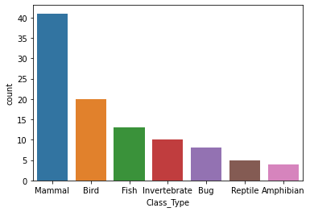

```python
import seaborn as sns
import matplotlib.pyplot as plt

sns.countplot(df3['Class_Type'],label="Count",
             order = df3['Class_Type'].value_counts().index) #sort bars
plt.show()
```

# B. Facetgrid

Using the FacetGrid from Seaborn, we can look at the columns to help us understand what features may be more helpful than others in classification

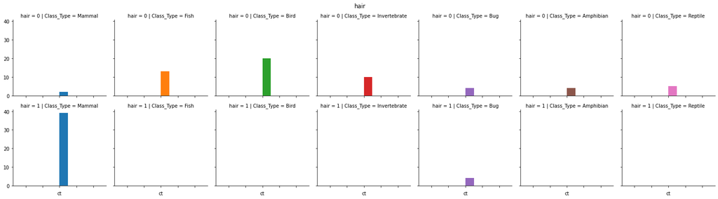

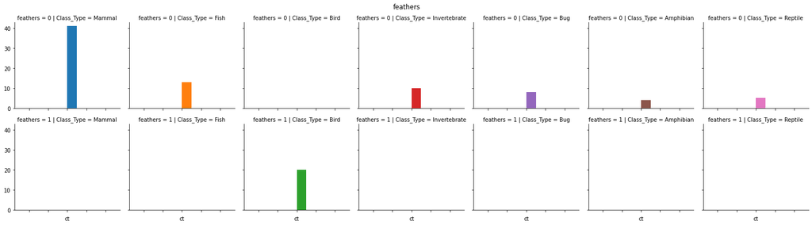

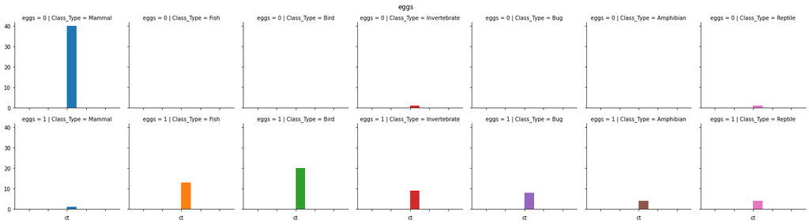

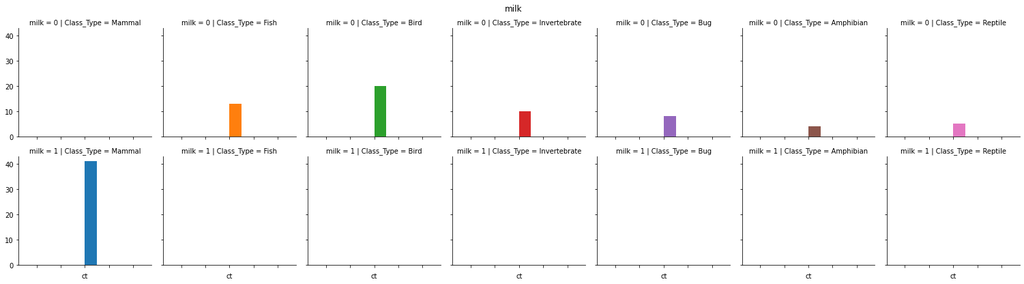

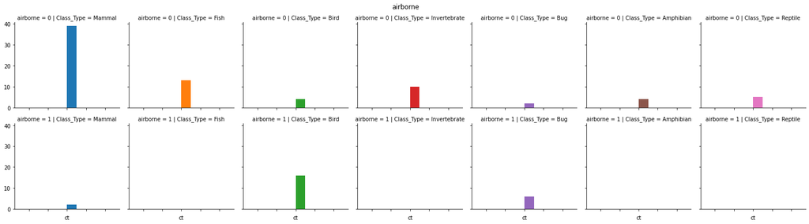

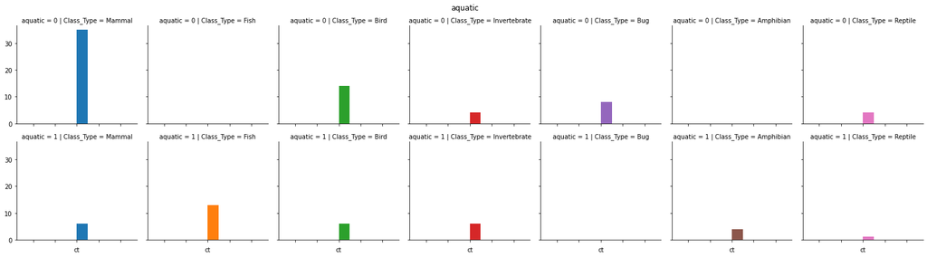

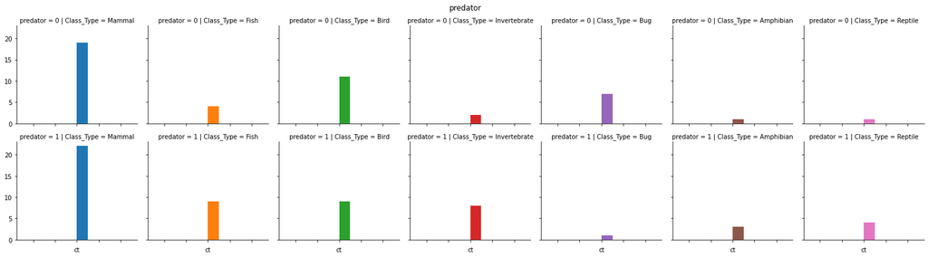

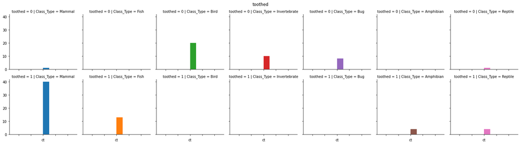

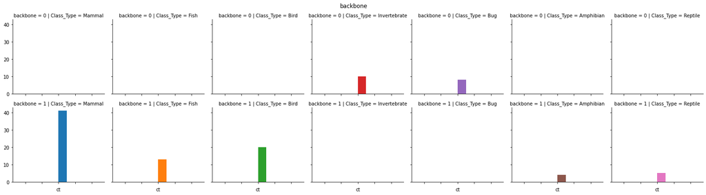

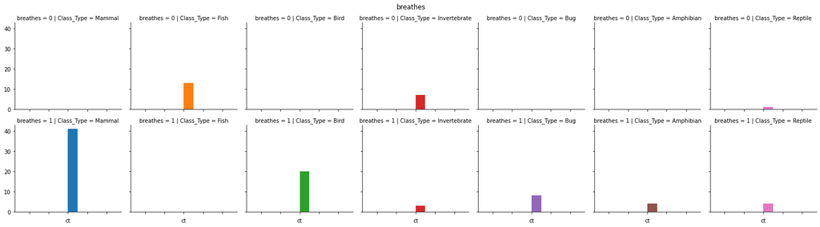

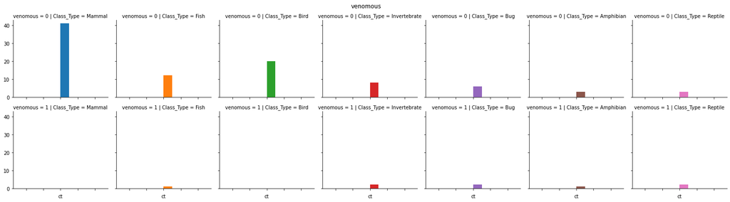

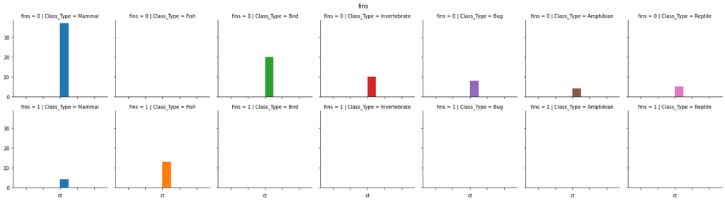

[3 more figures not shown]

```python
feature_names = ['hair','feathers','eggs','milk','airborne','aquatic','predator','toothed',
                 'backbone','breathes','venomous','fins','legs','tail','domestic']

df3['ct'] = 1

for f in feature_names:
    g = sns.FacetGrid(df3, col="Class_Type",  row=f, hue="Class_Type")
    g.map(plt.hist, "ct")
    g.set(xticklabels=[])
    plt.subplots_adjust(top=0.9)
    g.fig.suptitle(f)
```

# C. Heatmap

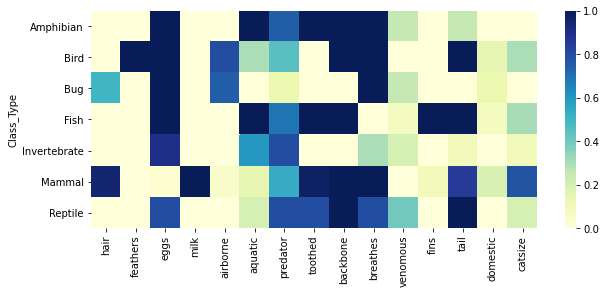

```python
gr = df3.groupby(by='Class_Type').mean()
columns = ['class_type','Class_Number','Number_Of_Animal_Species_In_Class','ct','legs'] #will handle legs separately since it's not binary
gr.drop(columns, inplace=True, axis=1)
plt.subplots(figsize=(10,4))
sns.heatmap(gr, cmap="YlGnBu")
```

# D. Stripplot

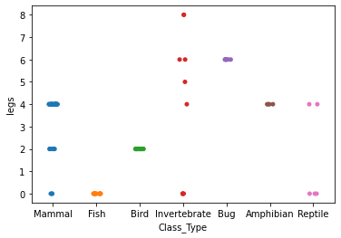

```python
sns.stripplot(x=df3["Class_Type"],y=df3['legs']) #show all observations along with some representation of the underlying distribution.
```

# 3. Data processing with algorithm and implementation

# A. Decision tree works if we use all of the features available to us and training with 20% of the data

```python
#specify the inputs (x = predictors, y = class)
X = df[feature_names]
y = df['class_type'] #there are multiple classes in this column

#split the dataframe into train and test groups
from sklearn.model_selection import train_test_split
X_train, X_test, y_train, y_test = train_test_split(X, y, train_size=.2, test_size=.8)

#specify the model to train with
from sklearn.tree import DecisionTreeClassifier
clf = DecisionTreeClassifier().fit(X_train, y_train)

from sklearn.metrics import classification_report
from sklearn.metrics import confusion_matrix
import warnings
import sklearn.exceptions
warnings.filterwarnings("ignore", category=sklearn.exceptions.UndefinedMetricWarning) #ignores warning that tells us dividing by zero equals zero

#let's see how well it worked
pred = clf.predict(X_test)
print('Accuracy of classifier on test set: {:.2f}'
     .format(clf.score(X_test, y_test)))
print()
print(confusion_matrix(y_test, pred))
print()
print(classification_report(y_test, pred))
```

```
Accuracy of classifier on test set: 0.77

[[31  0  0  0  0  0  0]
 [ 0 15  0  0  0  0  0]
 [ 0  0  0  0  0  5  0]
 [ 0  0  0 10  0  0  0]
 [ 0  0  0  0  0  4  0]
 [ 0  0  0  0  0  6  0]
 [ 0  0  0  0  0 10  0]]

              precision    recall  f1-score   support

           1       1.00      1.00      1.00        31
           2       1.00      1.00      1.00        15
           3       0.00      0.00      0.00         5
           4       1.00      1.00      1.00        10
           5       0.00      0.00      0.00         4
           6       0.24      1.00      0.39         6
           7       0.00      0.00      0.00        10

    accuracy                           0.77        81
   macro avg       0.46      0.57      0.48        81
weighted avg       0.71      0.77      0.72        81
```

```python
df3[['Class_Type','class_type']].drop_duplicates().sort_values(by='class_type') #this is the order of the labels in the confusion matrix above
```

|  | Class_Type | class_type |
| --- | --- | --- |
| 0 | Mammal | 1 |
| 11 | Bird | 2 |
| 62 | Reptile | 3 |
| 2 | Fish | 4 |
| 25 | Amphibian | 5 |
| 24 | Bug | 6 |
| 13 | Invertebrate | 7 |

# Features were the most important in this model

```python
imp = pd.DataFrame(clf.feature_importances_)
ft = pd.DataFrame(feature_names)
ft_imp = pd.concat([ft,imp],axis=1)
ft_imp.columns = ['Feature', 'Importance']
ft_imp.sort_values(by='Importance',ascending=False)
```

|  | Feature | Importance |
| --- | --- | --- |
| 3 | milk | 0.526718 |
| 1 | feathers | 0.290076 |
| 11 | fins | 0.183206 |
| 0 | hair | 0.000000 |
| 2 | eggs | 0.000000 |
| 4 | airborne | 0.000000 |
| 5 | aquatic | 0.000000 |
| 6 | predator | 0.000000 |
| 7 | toothed | 0.000000 |
| 8 | backbone | 0.000000 |
| 9 | breathes | 0.000000 |
| 10 | venomous | 0.000000 |
| 12 | legs | 0.000000 |
| 13 | tail | 0.000000 |
| 14 | domestic | 0.000000 |

# B. Decision tree works if we reduced the training set size to 10%

```python
X_train, X_test, y_train, y_test = train_test_split(X, y, train_size=.1, test_size=.9)

clf2 = DecisionTreeClassifier().fit(X_train, y_train)
pred = clf2.predict(X_test)
print('Accuracy of classifier on test set: {:.2f}'
     .format(clf2.score(X_test, y_test)))
print()
print(confusion_matrix(y_test, pred))
print()
print(classification_report(y_test, pred))
```

```
Accuracy of classifier on test set: 0.65

[[35  1  0  0  0  0  0]
 [ 0 16  0  0  0  0  0]
 [ 4  1  0  0  0  0  0]
 [13  0  0  0  0  0  0]
 [ 4  0  0  0  0  0  0]
 [ 0  0  0  0  0  0  8]
 [ 0  1  0  0  0  0  8]]

              precision    recall  f1-score   support

           1       0.62      0.97      0.76        36
           2       0.84      1.00      0.91        16
           3       0.00      0.00      0.00         5
           4       0.00      0.00      0.00        13
           5       0.00      0.00      0.00         4
           6       0.00      0.00      0.00         8
           7       0.50      0.89      0.64         9

    accuracy                           0.65        91
   macro avg       0.28      0.41      0.33        91
weighted avg       0.44      0.65      0.53        91
```